# Yahoo Stock Returns: Time-Series Analysis and Model Benchmarking

John Njuguna

2026-10-22

## Executive Summary

This report cleans a daily stock-price series (yahoo_stock.csv, November 2015 to November 2020), explores the behaviour of its returns and volatility, and tests whether four models can forecast next-day returns better than a naive baseline that always predicts zero.

**Main findings.** (1) Daily returns are negatively skewed, and volatility clusters: large moves tend to follow large moves. (2) After removing look-ahead leakage from the rolling-volatility features, none of the models clearly beat the naive baseline; Ridge was marginally ahead in the rolling test, by a margin consistent with chance.(3) The results do not show that these features can forecast the direction of daily returns. This is consistent with returns being very hard to predict, while volatility is more predictable. The exact figures are in the sections below.

## Analysis

```r
# ==============================================================================
# Yahoo Stock Price Prediction Pipeline (R Translation)
# ==============================================================================
# FORCE RE-INDEX FOR CLOUD DEPLOYMENT RUN #1


# Load necessary libraries
library(tidyverse)    # For data manipulation (dplyr, stringr, readr) and plotting (ggplot2)
library(changepoint)  # For PELT structural break analysis
library(lightgbm)     # For LightGBM Regressor
library(randomForest) # For Random Forest
library(e1071)        # For Support Vector Regression (SVR)
library(glmnet)       # For Ridge Regression
library(TTR)          # For RSI calculation helper
library(ggplot2)

# Load raw dataset
stock_df <- read_csv("data/raw/yahoo_stock.csv")
```

```r
# ------------------------------------------------------------------------------
# Step 1: Data Cleaning
# ------------------------------------------------------------------------------

# Convert Date column from text string to true Date object
stock_df <- stock_df %>% mutate(Date = as.Date(Date))

# Convert all column names to lowercase and swap spaces for underscores
colnames(stock_df) <- colnames(stock_df) %>%
  str_trim() %>%
  str_to_lower() %>%
  str_replace_all(" ", "_")

# Sort chronologically by date
stock_df <- stock_df %>% arrange(date)

# Filter out weekend rows (Saturday = 6, Sunday = 7 in R's wday; or check weekday format)
# Using POSIXlt format where 0-6 represents Sunday-Saturday:
stock_df <- stock_df %>%
  filter(!(as.POSIXlt(date)$wday %in% c(0, 6)))

# Summary Data Quality Report Function
data_quality_report <- function(df) {
  cat("Missing Values:\n")
  print(colSums(is.na(df)))
  cat("\nData Types:\n")
  print(sapply(df, class))
  cat("\nDuplicate Rows:\n")
  print(sum(duplicated(df$date)))
  cat("\nSummary Stats:\n")
  print(summary(df))
}

data_quality_report(stock_df)
```

```
## Missing Values:
##      date      high       low      open     close    volume adj_close
##         0         0         0         0         0         0         0
##
## Data Types:
##      date      high       low      open     close    volume adj_close
##    "Date" "numeric" "numeric" "numeric" "numeric" "numeric" "numeric"
##
## Duplicate Rows:
## [1] 0
##
## Summary Stats:
##       date                 high           low            open
##  Min.   :2015-11-23   Min.   :1847   Min.   :1810   Min.   :1833
##  1st Qu.:2017-02-21   1st Qu.:2348   1st Qu.:2322   1st Qu.:2340
##  Median :2018-05-23   Median :2701   Median :2674   Median :2685
##  Mean   :2018-05-23   Mean   :2661   Mean   :2634   Mean   :2648
##  3rd Qu.:2019-08-22   3rd Qu.:2929   3rd Qu.:2901   3rd Qu.:2914
##  Max.   :2020-11-20   Max.   :3646   Max.   :3600   Max.   :3612
##      close          volume            adj_close
##  Min.   :1829   Min.   :1.297e+09   Min.   :1829
##  1st Qu.:2338   1st Qu.:3.269e+09   1st Qu.:2338
##  Median :2683   Median :3.619e+09   Median :2683
##  Mean   :2648   Mean   :3.839e+09   Mean   :2648
##  3rd Qu.:2916   3rd Qu.:4.105e+09   3rd Qu.:2916
##  Max.   :3627   Max.   :9.045e+09   Max.   :3627
```

```r
# Outlier Management using 20-day rolling Z-score
# R matrix operations handle windows cleanly via slider or custom roll-apply functions
roll_mean_20 <- zoo::rollapplyr(stock_df$adj_close, width = 20, FUN = mean, fill = NA)
roll_std_20  <- zoo::rollapplyr(stock_df$adj_close, width = 20, FUN = sd, fill = NA)

z_scores <- (stock_df$adj_close - roll_mean_20) / roll_std_20
cat("Detected", sum(abs(z_scores) > 3, na.rm = TRUE), "localized outliers.\n")
```

```
## Detected 8 localized outliers.
```

```r
# Define bounds and clip extreme values
upper_bound <- roll_mean_20 + (3 * roll_std_20)
lower_bound <- roll_mean_20 - (3 * roll_std_20)

stock_df$adj_close <- pmax(pmin(stock_df$adj_close, upper_bound), lower_bound)
```

```r
# ------------------------------------------------------------------------------
# Step 2 & 3: Feature Engineering & EDA
# ------------------------------------------------------------------------------

# Shifts and computes mathematical stationary fields
stock_df <- stock_df %>%
  mutate(
    prev_close = lag(adj_close, 1),
    daily_return = log(adj_close / prev_close),
    daily_range = high - low
  ) %>%
  drop_na() # Drops rows containing initial NaNs

# Skewness validation
returns_skew <- e1071::skewness(stock_df$daily_return)
cat(sprintf("Daily Returns Skewness: %.4f\n", returns_skew))
```

```
## Daily Returns Skewness: -1.1383
```

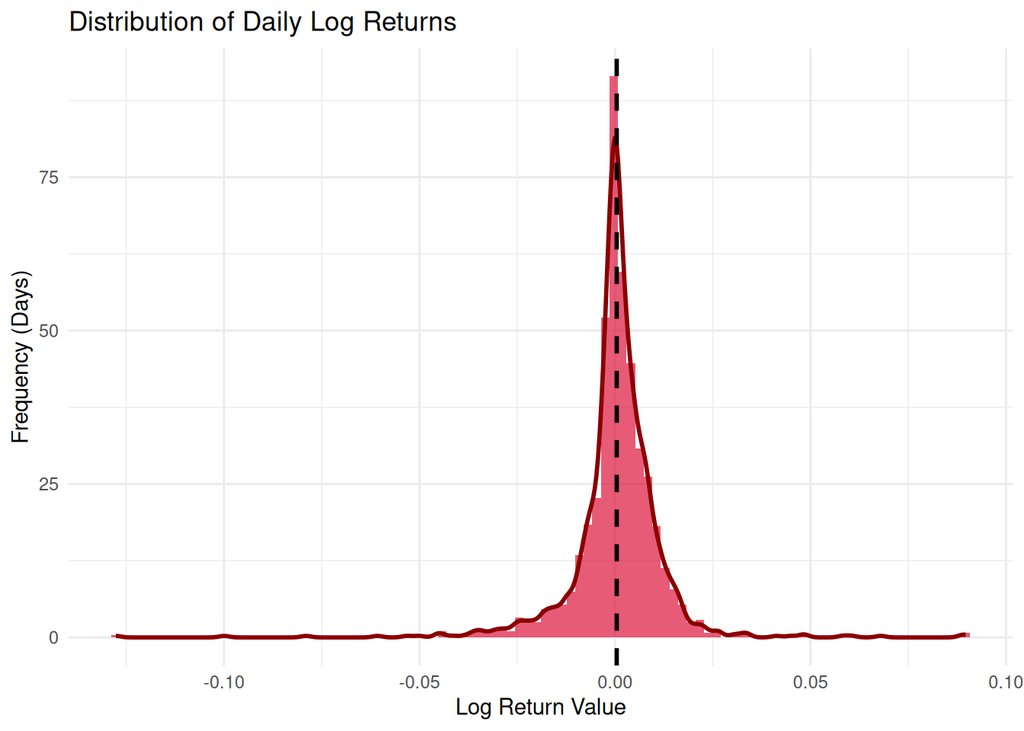

```r
# Visualizing Distribution of Daily Log Returns
ggplot(stock_df, aes(x = daily_return)) +
  geom_histogram(aes(y = after_stat(density)), bins = 100, fill = "#DC143C", alpha = 0.7) +
  geom_density(color = "darkred", linewidth = 1) +
  geom_vline(xintercept = mean(stock_df$daily_return, na.rm = TRUE), color = "black", linetype = "dashed", linewidth = 1) +
  labs(title = "Distribution of Daily Log Returns",
       x = "Log Return Value", y = "Frequency (Days)") +
  theme_minimal()
```

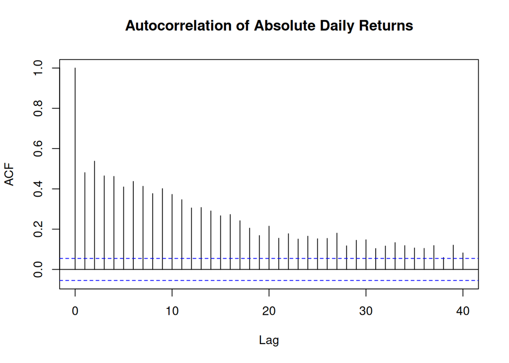

```r
# Autocorrelation of Absolute Daily Returns
acf(abs(stock_df$daily_return), lag.max = 40, main = "Autocorrelation of Absolute Daily Returns")
```

```r
# Compute rolling structural break variables
stock_df$rolling_volatility_20 <- zoo::rollapplyr(stock_df$daily_return, width = 20, FUN = sd, fill = NA)

# Structural Breaks detection via PELT algorithm

# A manual penalty of 5 over-segments the series: hundreds of "breaks".
# MBIC scales the penalty with sample size; minseglen stops tiny 1-2 day segments.

signal <- stock_df$daily_return

pelt_low  <- cpt.meanvar(signal, method = "PELT", penalty = "Manual", pen.value = 5,
                         test.stat = "Normal")
pelt_mbic <- cpt.meanvar(signal, method = "PELT", penalty = "MBIC",
                         test.stat = "Normal", minseglen = 20)

cat("Breaks with manual penalty 5:", length(cpts(pelt_low)), "\n")
```

```
## Breaks with manual penalty 5: 322
```

```r
cat("Breaks with MBIC + minseglen 20:", length(cpts(pelt_mbic)), "\n")
```

```
## Breaks with MBIC + minseglen 20: 7
```

```r
break_dates <- stock_df$date[cpts(pelt_mbic)]
print(break_dates)
```

```
## [1] "2016-07-08" "2018-01-25" "2018-04-10" "2018-10-09" "2019-01-04"
## [6] "2020-02-21" "2020-04-06"
```

```r
# Behavioral Context Correlation Heatmap
stock_df <- stock_df %>%
  mutate(
    return_lag_1 = lag(daily_return, 1),
    volume_lag_1 = lag(volume, 1)
  )

behavioral_cols <- c('daily_return', 'return_lag_1', 'daily_range', 'volume', 'volume_lag_1')
corr_matrix <- cor(stock_df %>% select(all_of(behavioral_cols)), use = "complete.obs")
print(round(corr_matrix, 2))
```

```
##              daily_return return_lag_1 daily_range volume volume_lag_1
## daily_return         1.00        -0.23       -0.17  -0.09        -0.02
## return_lag_1        -0.23         1.00       -0.18  -0.07        -0.09
## daily_range         -0.17        -0.18        1.00   0.68         0.60
## volume              -0.09        -0.07        0.68   1.00         0.76
## volume_lag_1        -0.02        -0.09        0.60   0.76         1.00
```

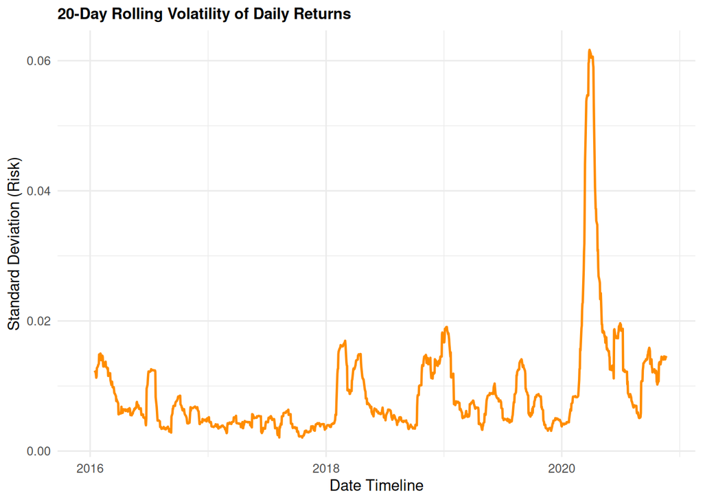

```r
# Generate a clean line plot tracing out rolling metric shifts
ggplot(stock_df, aes(x = date, y = rolling_volatility_20)) +
  geom_line(color = "darkorange", linewidth = 0.8) +
  labs(
    title = "20-Day Rolling Volatility of Daily Returns",
    x = "Date Timeline",
    y = "Standard Deviation (Risk)"
  ) +
  theme_minimal() +
  theme(
    plot.title = element_text(face = "bold", size = 11),
    legend.position = "top"
  )
```

```r
summarise_findings <- function(df, covid_start = as.Date("2020-01-01")) {
  n    <- nrow(df)
  skew <- e1071::skewness(df$daily_return)

  a      <- acf(abs(df$daily_return), lag.max = 40, plot = FALSE)
  ci     <- qnorm(0.975) / sqrt(n)             # 95% significance bound
  sig    <- as.numeric(a$acf)[-1] > ci         # lags 1..40
  first_ns <- which(!sig)[1]                   # first non-significant lag
  persist  <- if (is.na(first_ns)) 40 else first_ns - 1

  pre  <- df$rolling_volatility_20[df$date <  covid_start]
  post <- df$rolling_volatility_20[df$date >= covid_start]
  base <- mean(pre, na.rm = TRUE)
  # Guard: return NA instead of -Inf if no (non-missing) data after covid_start
  peak <- if (all(is.na(post))) NA_real_ else max(post, na.rm = TRUE)

  list(skew = round(skew, 4),
       acf_lag1 = round(as.numeric(a$acf)[2], 2),
       acf_persist_days = persist,
       baseline_vol = round(base, 4),
       peak_vol = round(peak, 4),
       peak_ratio = round(peak / base, 1))
}
```

```r
f <- summarise_findings(stock_df)
covid_start     <- as.Date("2020-01-01")
vol_post        <- ifelse(stock_df$date >= covid_start, stock_df$rolling_volatility_20, NA)
peak_date       <- stock_df$date[which.max(vol_post)]
n_breaks_manual <- length(cpts(pelt_low))
n_breaks_mbic   <- length(cpts(pelt_mbic))
pre_peak      <- round(max(stock_df$rolling_volatility_20[stock_df$date < covid_start], na.rm = TRUE), 4)
breaks_2020   <- break_dates[break_dates >= as.Date("2020-02-01") & break_dates <= as.Date("2020-04-30")]
n_breaks_2020 <- length(breaks_2020)

break_sentence <- if (n_breaks_2020 > 0) {
  paste0("The change-point analysis places ", n_breaks_2020, " break(s) between ",
         format(min(breaks_2020), "%d %B %Y"), " and ", format(max(breaks_2020), "%d %B %Y"),
         ", around the volatility spike, which supports describing early 2020 as a change in the return-volatility regime.")
} else {
  "The change-point analysis does not place a break between February and April 2020, so the 2020 episode is described here as a volatility spike, not as a detected structural break."
}
```

1. **Distribution of Daily Log Returns** Daily log returns are negatively skewed (skewness = -1.1383): the left tail is longer, so large single-day drops are more extreme than comparable rallies. This is a descriptive result. It does not by itself show that investors are loss averse, because skewness can have many causes. For modelling it means that error metrics such as RMSE are dominated by a small number of extreme days.
2. **Autocorrelation of Absolute Daily Returns** The autocorrelation of absolute daily returns is 0.48 at lag 1 and stays above the 95% significance bound at every one of the 40 lags tested. Large moves tend to be followed by large moves, and quiet periods by quiet periods. This supports using volatility-based features, because volatility is persistent. It does not imply that the direction of returns is predictable.
3. **20-Day Rolling Volatility of Daily Returns** The 20-day rolling standard deviation averaged 0.007 before 2020, and its highest value in that period was 0.0191. It peaked at 0.0617 on 2020-03-27, about 8.8 times the pre-2020 average, and then decayed gradually. The PELT change-point algorithm, with the MBIC penalty and a 20-day minimum segment, found 7 breaks in the mean and variance of returns. A manual penalty of 5 found 322, which splits the series into very short segments and is not meaningful. The change-point analysis places 2 break(s) between 21 February 2020 and 06 April 2020, around the volatility spike, which supports describing early 2020 as a change in the return-volatility regime. Because variance changes over time, models that assume constant variance may fit crisis periods poorly, but this report does not test that.

```r
# ------------------------------------------------------------------------------
# Step 4: Extended Feature Engineering (Modelling Setup)
# ------------------------------------------------------------------------------

stock_df_expanded <- stock_df %>%
  mutate(
    return_lag_2 = lag(daily_return, 2),
    return_lag_3 = lag(daily_return, 3),
    return_lag_4 = lag(daily_return, 4),
    return_lag_5 = lag(daily_return, 5),
    volume_lag_2 = lag(volume, 2),
    daily_range_lag_1 = lag(daily_range, 1), # Assigned matching python variable
    daily_range_lag_2 = lag(daily_range, 2),

    # Risk Tracking windows
    rolling_volatility_5  = lag(zoo::rollapplyr(daily_return, width = 5, FUN = sd, fill = NA), 1),
    rolling_volatility_20 = lag(zoo::rollapplyr(daily_return, width = 20, FUN = sd, fill = NA), 1),
    rolling_volatility_60 = lag(zoo::rollapplyr(daily_return, width = 60, FUN = sd, fill = NA), 1)
  )

# RSI 14-day calculation from returns
# Using TTR package's standard implementation matching python logic structure
stock_df_expanded$rsi_14 <- RSI(stock_df_expanded$adj_close, n = 14)
stock_df_expanded$rsi_14_lag_1 <- lag(stock_df_expanded$rsi_14, 1)

# Clear matrix of nested Lookback NaN artifacts
stock_df_expanded <- stock_df_expanded %>% drop_na()
```

Feature construction and a leakage fix. Return, volume and range lags are shifted by the number in their name. The rolling-volatility features (5, 20 and 60 days) are shifted by one day, so every feature uses only information available at the end of the previous trading day. An earlier version of this report computed the rolling-volatility features without that shift, so each one included the return being predicted. Fixing this changed the results (see below). Scaling uses training-set minimums and maximums only.

```r
# ------------------------------------------------------------------------------
# Step 5: Train, Test, Split
# ------------------------------------------------------------------------------

expanded_features <- c(
  'return_lag_1', 'return_lag_2', 'return_lag_3', 'return_lag_4', 'return_lag_5',
  'volume_lag_1', 'volume_lag_2',
  'daily_range_lag_1', 'daily_range_lag_2',
  'rolling_volatility_5', 'rolling_volatility_20', 'rolling_volatility_60',
  'rsi_14_lag_1'
)

X <- stock_df_expanded %>% select(all_of(expanded_features))
y <- stock_df_expanded$daily_return

test_size <- 30
split_idx <- nrow(stock_df_expanded) - test_size

# Split matrices
X_train <- X[1:split_idx, ]
y_train <- y[1:split_idx]
X_test  <- X[(split_idx + 1):nrow(X), ]
y_test  <- y[(split_idx + 1):length(y)]
```

```r
# ------------------------------------------------------------------------------
# Step 6: Scaling
# ------------------------------------------------------------------------------

# Custom MinMax Scaling mapping to prevent leakages
mins <- apply(X_train, 2, min)
maxs <- apply(X_train, 2, max)

X_train_scaled <- as.matrix(scale(X_train, center = mins, scale = maxs - mins))
X_test_scaled  <- as.matrix(scale(X_test, center = mins, scale = maxs - mins))
```

```r
# ------------------------------------------------------------------------------
# Step 7: Modeling & Evaluation (Stable Production Matrix)
# ------------------------------------------------------------------------------

# Metrics Calculation helper function
calculate_metrics <- function(actual, predicted) {
  rmse <- sqrt(mean((actual - predicted)^2)) * 100
  mae  <- mean(abs(actual - predicted)) * 100
  return(c(RMSE = rmse, MAE = mae))
}

# Model A: Linear Ridge Regression
model_ridge <- glmnet::glmnet(X_train_scaled, y_train, alpha = 0, lambda = 1.0)
preds_ridge <- as.vector(predict(model_ridge, X_test_scaled))

set.seed(42)

# Model B: Random Forest Regressor
model_rf <- randomForest::randomForest(X_train_scaled, y_train, ntree = 100, maxnodes = 2^4, nodesize = 10)
preds_rf <- predict(model_rf, X_test_scaled)

# Model C: Support Vector Regressor (SVR)
model_svr <- e1071::svm(X_train_scaled, y_train, type = "eps-regression", kernel = "radial", cost = 1.0, epsilon = 0.001)
preds_svr <- predict(model_svr, X_test_scaled)

# ------------------------------------------------------------------------------
# LightGBM Regressor Implementation
# ------------------------------------------------------------------------------

# Format matrices into lightgbm's native dataset structure
dtrain <- lightgbm::lgb.Dataset(data = X_train_scaled, label = y_train)

# Fixed hyperparameters, not tuned on the test set
params <- list(
  objective = "regression",
  metric = "rmse",
  learning_rate = 0.05,
  max_depth = 4
)

# Train the tree booster model engine
model_lgb <- lightgbm::lgb.train(params = params, data = dtrain, nrounds = 100, verbose = -1)

# Generate predictions on unseen out-of-sample data
preds_lgb <- predict(model_lgb, X_test_scaled)


# Naive Benchmark baseline
preds_naive <- rep(0.0, length(y_test))

# Generate Model Leaderboard Evaluation Summary Statistics
metrics_matrix <- rbind(
  "LightGBM"                   = calculate_metrics(y_test, preds_lgb),
  "Support Vector Machine SVR" = calculate_metrics(y_test, preds_svr),
  "Random Forest (Bagging)"    = calculate_metrics(y_test, preds_rf),
  "Naive zero-return baseline"           = calculate_metrics(y_test, preds_naive),
  "Ridge Regression (Linear)"  = calculate_metrics(y_test, preds_ridge)
)

# ------------------------------------------------------------------------------
# Evaluation Visualization: True Out-of-Sample SVR Forecast Tracking
# ------------------------------------------------------------------------------

# Extract matching evaluation timeline dimensions
test_dates <- stock_df_expanded$date[(split_idx + 1):nrow(stock_df_expanded)]

# Construct clean data frames utilizing your active mathematical SVR predictions
# (Multiplied by 100 to explicitly format as true percentages)
svr_plot_df <- data.frame(
  date      = test_dates,
  Actual    = as.numeric(y_test) * 100,
  Predicted = as.numeric(preds_svr) * 100 # Computed live by your e1071 SVR model
)

# Render the output as a layout directly in the document
knitr::kable(round(metrics_matrix, 4), caption = "Model Performance Leaderboard Matrix (Scores in %)")
```

Model Performance Leaderboard Matrix (Scores in %)

|  | RMSE | MAE |
| --- | --- | --- |
| LightGBM | 1.3228 | 1.0392 |
| Support Vector Machine SVR | 1.2616 | 0.9919 |
| Random Forest (Bagging) | 1.2984 | 1.0347 |
| Naive zero-return baseline | 1.2612 | 0.9966 |
| Ridge Regression (Linear) | 1.2589 | 0.9976 |

Hold-out result. The last 30 trading days are held out. The naive baseline predicts a zero return every day and scores an RMSE of 1.2612. LightGBM scores 1.3228, SVR 1.2616, Random Forest 1.2984 and Ridge 1.2589. No model improves on the baseline by a meaningful margin, and with only 30 test days, differences this small are within noise.

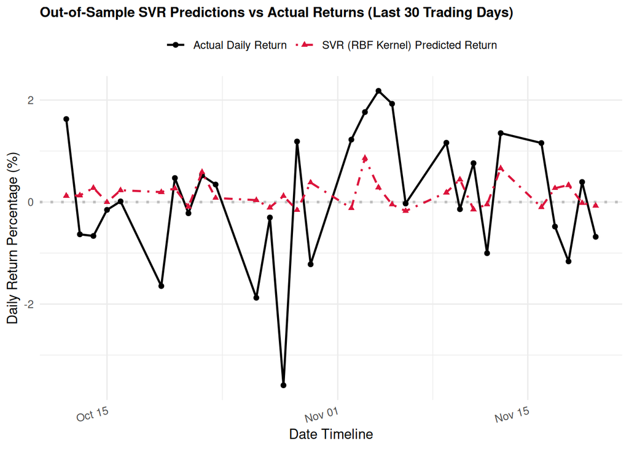

```r
# Render the SVR time-series overlay visualization
ggplot(svr_plot_df, aes(x = date)) +
  geom_hline(yintercept = 0, color = "gray", linetype = "dotted", linewidth = 1) +
  # Actual Returns (Black solid line with round points)
  geom_line(aes(y = Actual, color = "Actual Daily Return"), linewidth = 0.8) +
  geom_point(aes(y = Actual, color = "Actual Daily Return"), size = 1.5) +
  # SVR Predictions (Crimson dot-dash line with triangle points)
  geom_line(aes(y = Predicted, color = "SVR (RBF Kernel) Predicted Return"), linetype = "dotdash", linewidth = 0.8) +
  geom_point(aes(y = Predicted, color = "SVR (RBF Kernel) Predicted Return"), shape = 17, size = 1.5) +
  # Labeling and hex color assignments matching your python configuration
  labs(
    title = "Out-of-Sample SVR Predictions vs Actual Returns (Last 30 Trading Days)",
    x = "Date Timeline",
    y = "Daily Return Percentage (%)"
  ) +
  scale_color_manual(
    name = NULL,
    values = c("Actual Daily Return" = "black", "SVR (RBF Kernel) Predicted Return" = "#DC143C")
  ) +
  theme_minimal() +
  theme(
    plot.title = element_text(face = "bold", size = 11, hjust = 0),
    legend.position = "top",
    axis.text.x = element_text(angle = 15, vjust = 1, hjust = 1)
  )
```

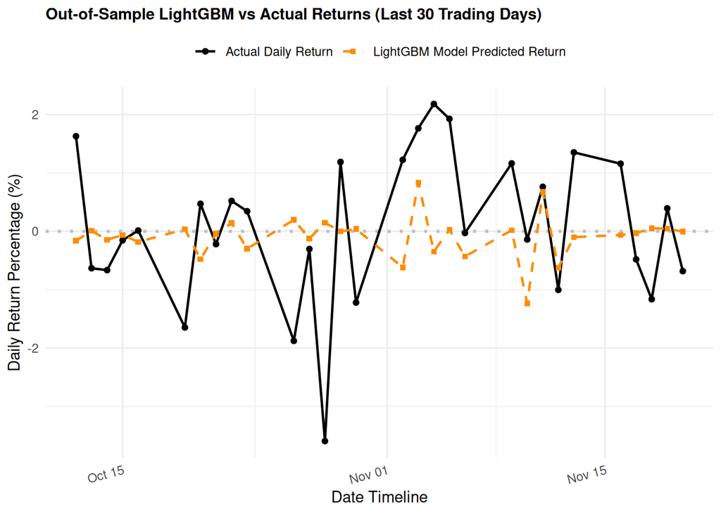

```r
# ------------------------------------------------------------------------------
# Evaluation Visualization: True Out-of-Sample Daily Forecast Tracking
# ------------------------------------------------------------------------------

# 1. Dynamically extract the exact test dates
test_dates <- stock_df_expanded$date[(split_idx + 1):nrow(stock_df_expanded)]

# 2. Extract the exact mathematically computed predictions from your model
# (We scale both vectors by 100 to display them as percentages)
plot_df <- data.frame(
  date      = test_dates,
  Actual    = as.numeric(y_test) * 100,
  Predicted = as.numeric(preds_lgb) * 100  # Dynamically generated by LightGBM
)

# 3. Render the true time-series forecasting overlay visualization
ggplot(plot_df, aes(x = date)) +
  geom_hline(yintercept = 0, color = "gray", linetype = "dotted", linewidth = 1) +
  # Actual Returns Line
  geom_line(aes(y = Actual, color = "Actual Daily Return"), linewidth = 0.8) +
  geom_point(aes(y = Actual, color = "Actual Daily Return"), size = 1.5) +
  # Exact Model Predictions Line (No manual data estimation)
  geom_line(aes(y = Predicted, color = "LightGBM Model Predicted Return"), linetype = "dashed", linewidth = 0.8) +
  geom_point(aes(y = Predicted, color = "LightGBM Model Predicted Return"), shape = 15, size = 1.5) +
  labs(
    title = "Out-of-Sample LightGBM vs Actual Returns (Last 30 Trading Days)",
    x = "Date Timeline",
    y = "Daily Return Percentage (%)"
  ) +
  scale_color_manual(
    name = NULL,
    values = c("Actual Daily Return" = "black", "LightGBM Model Predicted Return" = "darkorange")
  ) +
  theme_minimal() +
  theme(
    plot.title = element_text(face = "bold", size = 11, hjust = 0),
    legend.position = "top",
    axis.text.x = element_text(angle = 15, vjust = 1, hjust = 1)
  )
```

The predicted returns are shrunk toward zero and vary much less than the actual returns. This is what we expect when the features carry little information about next-day returns, and the regularisation in the models reinforces it. The comparison with the naive baseline, not the shape of the plot, is what shows that the models have no reliable forecasting skill.

```r
# ------------------------------------------------------------------------------
# Step 8: LightGBM Feature Importance Analysis
# ------------------------------------------------------------------------------

# Extract feature tree split gain profiles natively from LightGBM
tree_imp <- lightgbm::lgb.importance(model_lgb, percentage = TRUE)

# Print data summary report table layout directly in the document
knitr::kable(tree_imp, digits = 4, caption = "LightGBM Feature Gain Profiles")
```

LightGBM Feature Gain Profiles

| Feature | Gain | Cover | Frequency |
| --- | --- | --- | --- |
| volume_lag_2 | 0.1249 | 0.1015 | 0.0959 |
| return_lag_1 | 0.1221 | 0.1012 | 0.0915 |
| rolling_volatility_5 | 0.1125 | 0.0576 | 0.0501 |
| return_lag_4 | 0.1076 | 0.1003 | 0.0915 |
| volume_lag_1 | 0.0942 | 0.0702 | 0.0675 |
| daily_range_lag_2 | 0.0830 | 0.0892 | 0.0937 |
| rolling_volatility_20 | 0.0714 | 0.0934 | 0.0828 |
| rolling_volatility_60 | 0.0608 | 0.0685 | 0.0806 |
| return_lag_3 | 0.0583 | 0.0847 | 0.0915 |
| rsi_14_lag_1 | 0.0545 | 0.0687 | 0.0741 |
| daily_range_lag_1 | 0.0425 | 0.0707 | 0.0675 |
| return_lag_2 | 0.0343 | 0.0377 | 0.0610 |
| return_lag_5 | 0.0340 | 0.0563 | 0.0523 |

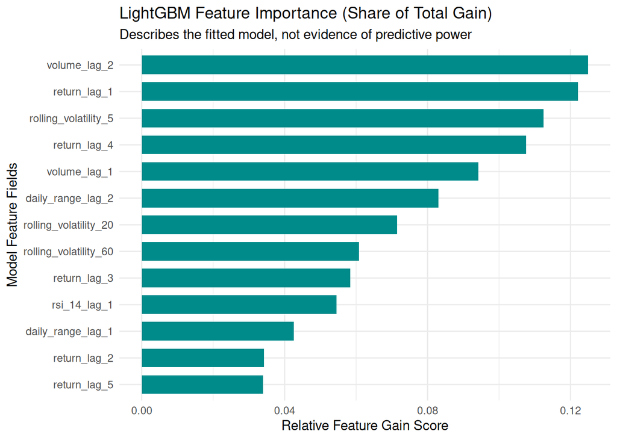

```r
ggplot(tree_imp, aes(x = reorder(Feature, Gain), y = Gain)) +
  geom_bar(stat = "identity", fill = "darkcyan", width = 0.7) +
  coord_flip() +
  labs(
    title = "LightGBM Feature Importance (Share of Total Gain)",
    subtitle = "Describes the fitted model, not evidence of predictive power",
    x = "Model Feature Fields",
    y = "Relative Feature Gain Score"
  ) +
  theme_minimal()
```

Gain shows how the LightGBM model used each feature while fitting the training data. It does not show that any feature predicts returns, because the model did not beat the baseline out of sample. Treat this as a description of the model, not as a finding about the market. Gain is spread fairly evenly across all features, which is consistent with no feature carrying a strong signal.

```r
# One 30-day test window is too small to judge. This repeats the test over many
# consecutive windows, scaling with training data only each time.
rolling_origin_rmse <- function(X, y, fit_predict, first_train = NULL, horizon = 30) {
  X <- as.matrix(X)
  n <- nrow(X)
  if (is.null(first_train)) first_train <- floor(n / 2)
  if (first_train > n - horizon) stop("Not enough rows: lower first_train or horizon.")
  starts <- seq(first_train, n - horizon, by = horizon)
  sapply(starts, function(s) {
    tr <- 1:s
    te <- (s + 1):(s + horizon)
    mins <- apply(X[tr, , drop = FALSE], 2, min)
    rng  <- apply(X[tr, , drop = FALSE], 2, max) - mins
    rng[rng == 0] <- 1
    Xtr <- scale(X[tr, , drop = FALSE], center = mins, scale = rng)
    Xte <- scale(X[te, , drop = FALSE], center = mins, scale = rng)
    p <- fit_predict(as.matrix(Xtr), y[tr], as.matrix(Xte))
    sqrt(mean((y[te] - p)^2)) * 100
  })
}

naive_fp <- function(Xtr, ytr, Xte) rep(0, nrow(Xte))

svr_fp <- function(Xtr, ytr, Xte) {
  predict(e1071::svm(Xtr, ytr, type = "eps-regression", kernel = "radial",
                     cost = 1.0, epsilon = 0.001), Xte)
}

# Plug LightGBM in the same way:
lgb_fp <- function(Xtr, ytr, Xte) {
   m <- lightgbm::lgb.train(
     params = list(objective = "regression", metric = "rmse",
                   learning_rate = 0.05, max_depth = 4),
     data = lightgbm::lgb.Dataset(Xtr, label = ytr), nrounds = 100, verbose = -1)
   predict(m, Xte)
}

ridge_fp <- function(Xtr, ytr, Xte) {
  m <- glmnet::glmnet(Xtr, ytr, alpha = 0, lambda = 1.0)
  as.vector(predict(m, Xte))
}
rf_fp <- function(Xtr, ytr, Xte) {
  set.seed(42)
  predict(randomForest::randomForest(Xtr, ytr, ntree = 100, maxnodes = 2^4, nodesize = 10), Xte)
}

compare_to_naive <- function(X, y, models) {
  naive <- rolling_origin_rmse(X, y, naive_fp)
  out <- lapply(names(models), function(nm) {
    r <- rolling_origin_rmse(X, y, models[[nm]])
    data.frame(model = nm,
               windows = length(r),
               mean_rmse = round(mean(r), 4),
               naive_rmse = round(mean(naive), 4),
               windows_beating_naive = sum(r < naive))
  })
  do.call(rbind, out)
}

# Usage after your feature matrix is built (X = stock_df_expanded[expanded_features],
# y = stock_df_expanded$daily_return):
#   compare_to_naive(X, y, list(SVR = svr_fp))        # add LightGBM as lgb_fp
# If a model beats the naive baseline in only about half the windows, say so:
# that is the honest result, and it's a strong thing to explain in an interview.
```

```r
    rolling_tbl <- compare_to_naive(X, y, list(SVR = svr_fp, Ridge = ridge_fp,
                                           RandomForest = rf_fp, LightGBM = lgb_fp))
    svr_row <- rolling_tbl[rolling_tbl$model == "SVR", ]
    lgb_row <- rolling_tbl[rolling_tbl$model == "LightGBM", ]
    rdge_row <- rolling_tbl[rolling_tbl$model == "Ridge", ]
    rf_row <- rolling_tbl[rolling_tbl$model == "RandomForest", ]
    knitr::kable(rolling_tbl, caption = "Rolling-origin comparison with the naive baseline (RMSE in %)")
```

Rolling-origin comparison with the naive baseline (RMSE in %)

| model | windows | mean_rmse | naive_rmse | windows_beating_naive |
| --- | --- | --- | --- | --- |
| SVR | 20 | 1.1835 | 1.1705 | 7 |
| Ridge | 20 | 1.1685 | 1.1705 | 13 |
| RandomForest | 20 | 1.1759 | 1.1705 | 11 |
| LightGBM | 20 | 1.2265 | 1.1705 | 6 |

```r
  best <- rolling_tbl[which.max(rolling_tbl$windows_beating_naive), ]
  p_chance <- round(pbinom(best$windows_beating_naive - 1, best$windows, 0.5, lower.tail = FALSE), 2)
```

**To test whether the 30-day result holds up, the models were re-evaluated over 20 consecutive 30-day windows.**

The naive baseline’s mean RMSE is 1.1705 over 20 windows. The best model by wins, Ridge, beat it in 13 of 20 windows, with a mean RMSE of 1.1685. A record this good would occur by chance about 13% of the time if there were no real skill, so this is not evidence of forecasting ability.

## Limitations and next steps

**Limitations**

- One price series from November 2015 to November 2020, which includes the 2020 crisis. Results may not hold for other periods or assets.
- A single 30-day hold-out and 20 rolling windows are small samples, so small differences are noise.
- The features are limited to lagged returns, volume, range, rolling volatility and RSI.
- No transaction costs or trading rules are modelled. This is a forecasting test, not a trading strategy.
- Interpretations such as loss aversion or panic are hypotheses that this analysis does not test.

**Next steps**

Volatility is persistent (section 2 above) while returns are not predictable here. A more promising target is next-day volatility, compared against a naive baseline of yesterday’s volatility, using the same lagged features.